# Curso PostgreSQL

[figure not shown]

**Autor: Luis Fernando Apáez Álvarez**  
-Curso PyM-  
Tarea 1  
Fecha: Marzo del 2023

### Ejercicios

#### Parte I

1. Crea una tabla nueva en el proyecto de la papelería con al menos 4 columnas

   a. Cambia en el nombre de dos columnas de dicha tabla

   b. Cambia el tipo de dato de una columna

   c. Elimina una columna

   d. Cambia el nombre de la tabla

   e. Finalmente, elimina la tabla.

Te recomiendo escribir en un script todo el código del ejercicio anterior e irlos guardando en algún folder de tu pc.

Para descargar el script SQL de *pgAdmin* nos vamos a *Save As* en:

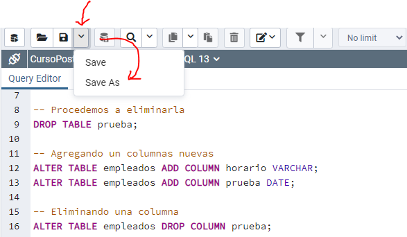

Es importante saber la ruta donde deseas guardar el script SQL. Una vez que pulsamos en *Save As* se abrirá la siguiente pestaña

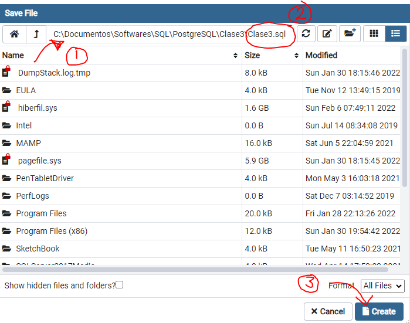

donde

1. Colocamos la ruta donde guardaremos nuestro archivo.
2. Agregamos al final de la ruta el nombre que deseamos ponerle a nuestro archivo, en nuestro caso colocamos *Clase3.sql*. Es importante colocar la terminación .sql el final del nombre de nuestro archivo.
3. Finalmente pulsamos `Create`.

#### Parte II

1. En la clase 1 definimos las primeras tres tablas de nuestra base de datos. De hecho, omitimos la definición de una columna en la tabla `productos`. Pues dicha tabla la definimos empleando el código

   ```
   CREATE TABLE productos(
      id_productos SERIAL,
      cantidad_almacen INT,
      precio REAL);
   ```

   y nos faltó la columna `nombre_producto` cuyo tipo de dato es `VARCHAR`. De tal manera, utiliza lenguaje DDL para agregar dicha columna a la tabla `productos`.
2. Realiza al menos tres inserciones en cada una de las tablas que tengas en tu base de datos (referente al proyecto de la papelería)
3. Elimina dos filas de cualquiera de las tablas
4. Modifica el valor de un registro por cada tabla de tu base de datos.